# GEO 200CN Lab 5

Kenneth Larrieu

April 29, 2019

# Spatial Autocorrelation

## The area of a polygon

```r
# import rspatial package
library(rspatial)
```

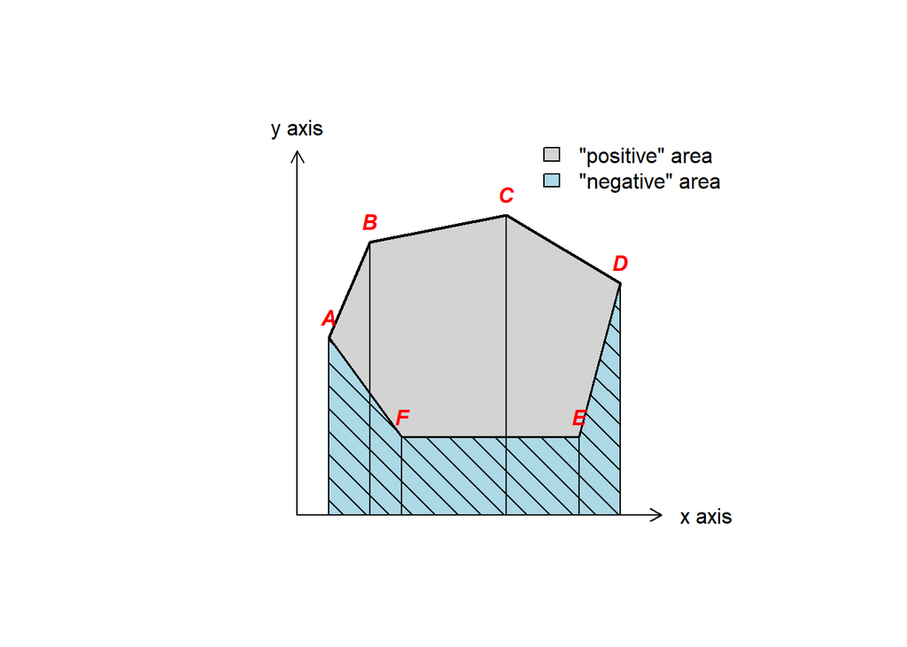

```r
# create polygon coords
pol <- matrix(c(1.7, 2.6, 5.6, 8.1, 7.2, 3.3, 1.7, 4.9, 7, 7.6, 6.1, 2.7, 2.7, 4.9), ncol=2)

# import raster library and make coords into polygon object
library(raster)
sppol <- spPolygons(pol)

# create negative polygon
negpol <- rbind(pol[c(1,6:4),], cbind(pol[4,1], 0), cbind(pol[1,1], 0))
spneg <- spPolygons(negpol)

# plot them
cols <- c('light gray', 'light blue')
plot(sppol, xlim=c(1,9), ylim=c(1,10), col=cols[1], axes=FALSE, xlab='', ylab='',
      lwd=2, yaxs="i", xaxs="i")
plot(spneg, col=cols[2], add=T)
plot(spneg, add=T, density=8, angle=-45, lwd=1)
segments(pol[,1], pol[,2], pol[,1], 0)
text(pol, LETTERS[1:6], pos=3, col='red', font=4)
arrows(1, 1, 9, 1, 0.1, xpd=T)
arrows(1, 1, 1, 9, 0.1, xpd=T)
text(1, 9.5, 'y axis', xpd=T)
text(10, 1, 'x axis', xpd=T)
legend(6, 9.5, c('"positive" area', '"negative" area'), fill=cols, bty = "n")
```

```r
# compute polygon area
# get clockwise adjacent points
p <- rbind(pol, pol[1,])
# take differenct in x
x <- p[-1,1] - p[-nrow(p),1]
# take average y value
y <- (p[-1,2] + p[-nrow(p),2]) / 2
# sum their product
sum(x * y)
```

```
## [1] 23.81
```

## Contact Numbers

```r
# Lower 48 data
usa <- raster::getData('GADM', country='USA', level=1)
usa <- usa[! usa$NAME_1 %in% c('Alaska', 'Hawaii'), ]

library(spdep)
wus <- poly2nb(usa, row.names=usa$OBJECTID, queen=FALSE)
wus
```

```
## Neighbour list object:
## Number of regions: 49
## Number of nonzero links: 220
## Percentage nonzero weights: 9.162849
## Average number of links: 4.489796
```

```r
# create adjacency matrix (style = B = binary)
wmus <- nb2mat(wus, style='B', zero.policy = TRUE)
dim(wmus)
```

```
## [1] 49 49
```

```r
# load county data
counties <- raster::getData('GADM', country='USA', level=2)
county_neighbors = poly2nb(counties, row.names = counties$OBJECTID, queen=FALSE)
county_w = nb2mat(county_neighbors, style='B', zero.policy=TRUE)
```

Which county has 13 neighbors?

```r
county_names = paste(counties$NAME_2, counties$NAME_1, sep=' County, ')
county_names[which(colSums(county_w) == 13 & counties$TYPE_2 == 'County')]
```

```
## [1] "Washoe County, Nevada"
```

## Spatial Structure

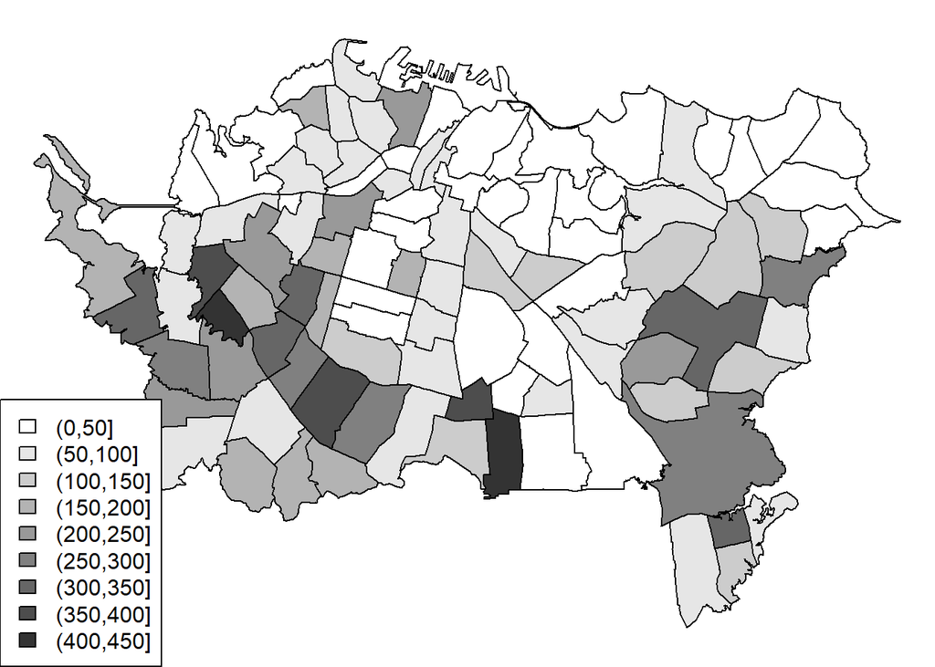

```r
# load auckland data
pols <- sp_data("auctb.rds")

# plot areas shaded by number of TB cases
par(mai=c(0,0,0,0))
classes <- seq(0,450,50)
cuts <- cut(pols$TB, classes)
n <- length(classes)
cols <- rev(gray(0:n / n))
plot(pols, col=cols[as.integer(cuts)])
legend('bottomleft', levels(cuts), fill=cols)
```

```r
# rook's case neighborhood
wr <- poly2nb(pols, row.names=pols$Id, queen=FALSE)
class(wr)
```

```
## [1] "nb"
```

```r
summary(wr)
```

[output not shown]

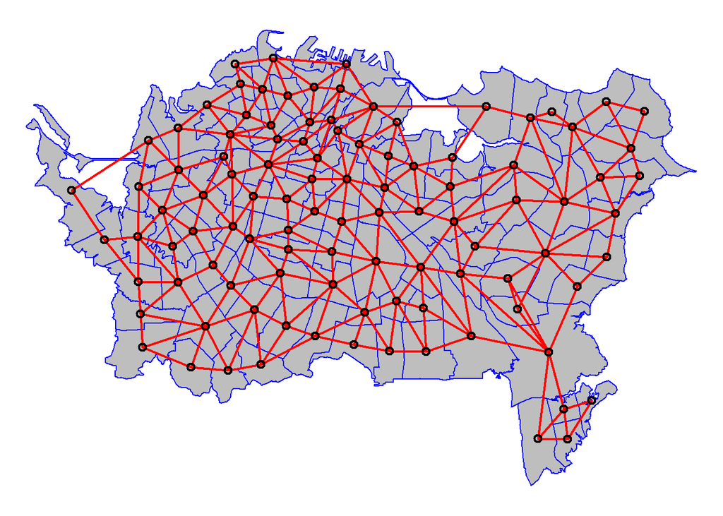

```r
par(mai=c(0,0,0,0))
plot(pols, col='gray', border='blue')
xy <- coordinates(pols)
plot(wr, xy, col='red', lwd=2, add=TRUE)
```

```r
# create a matrix from the links list
wm <- nb2mat(wr, style='B')
dim(wm)
```

```
## [1] 103 103
```

```r
wr[1:6]
```

```
## [[1]]
## [1] 28 53 73 74 75 76 77
##
## [[2]]
## [1] 30 73 74
##
## [[3]]
## [1] 33 35 44 53
##
## [[4]]
## [1] 28 29 31 41 43 75 76 97
##
## [[5]]
## [1] 32 37 39 64 78 79 81 86
##
## [[6]]
## [1]  7 11
```

**Question 1**:Explain the meaning of the first lines returned by `wr[1:6]`.

Returns a list of lists, where for each index it returns a list of all its neighbors’ indices.

## Spatial Autocorrelation

```r
# number of regions
n <- length(pols)
# get y value (TB incidents)
y <- pols$TB
# get average y value
ybar <- mean(y)
# deviations from mean
dy <- y - ybar
# expand into grid of all possible pairs
g <- expand.grid(dy, dy)
# yi * yj = product of value in first column and second
yiyj <- g[,1] * g[,2]
# make a matrix of these products (yi - ybar)(yj - ybar)
pm <- matrix(yiyj, ncol=n)

# multiply with weight matrix
pmw = pm * wm
# sum to get covariance measure
spmw = sum(pmw)

# normalize: divide by sum of weights as well as variance
MI = spmw/(sum(wm) * sum(dy^2)/n)
MI
```

```
## [1] 0.2643226
```

```r
# expected Moran's I
EI = -1/(n-1)
```

Repeating the same analysis using `spdep`:

```r
# compute spatial weights list
ww <- nb2listw(wr, style='B')
# moran(y, weights_list, number of regions, sum of weight matrix)
moran(pols$TB, ww, n=length(ww$neighbours), S0=Szero(ww))
```

```
## $I
## [1] 0.2643226
##
## $K
## [1] 3.517442
```

testing for significance:

```r
moran.test(pols$TB, ww, randomisation=FALSE)
```

```
##
##  Moran I test under normality
##
## data:  pols$TB
## weights: ww
##
## Moran I statistic standard deviate = 4.478, p-value = 3.767e-06
## alternative hypothesis: greater
## sample estimates:
## Moran I statistic       Expectation          Variance
##       0.264322626      -0.009803922       0.003747384
```

```r
moran.mc(pols$TB, ww, nsim=99)
```

```
##
##  Monte-Carlo simulation of Moran I
##
## data:  pols$TB
## weights: ww
## number of simulations + 1: 100
##
## statistic = 0.26432, observed rank = 100, p-value = 0.01
## alternative hypothesis: greater
```

**Question 2**: How do you interpret these results (the significance tests)?

Since the p-value is < 0.05, this indicates that the autocorrelation of TB between regions is significantly greater than would be expected due to randomness.

**Question 3**: What would a good value be for `nsim`?

As mentioned in OSU, a good value for `nsim` would be 999.

Making a Moran scatter plot:

```r
# number of features
n <- length(pols)
# get y values of neighboring features
# wm * y : each column has y value if neighbor or zero if not neighbor
ms <- cbind(id=rep(1:n, each=n), y=rep(y, each=n), value=as.vector(wm * y))
# get nonzero values
ms <- ms[ms[,3] > 0, ]
# take average of each
ams <- aggregate(ms[,2:3], list(ms[,1]), FUN=mean)
ams <- ams[,-1]
colnames(ams) <- c('y', 'spatially lagged y')
head(ams)
```

```
##     y spatially lagged y
## 1 271           135.1429
## 2 148           154.3333
## 3  37           142.2500
## 4 324           142.6250
## 5  99            71.6250
## 6  49            14.5000
```

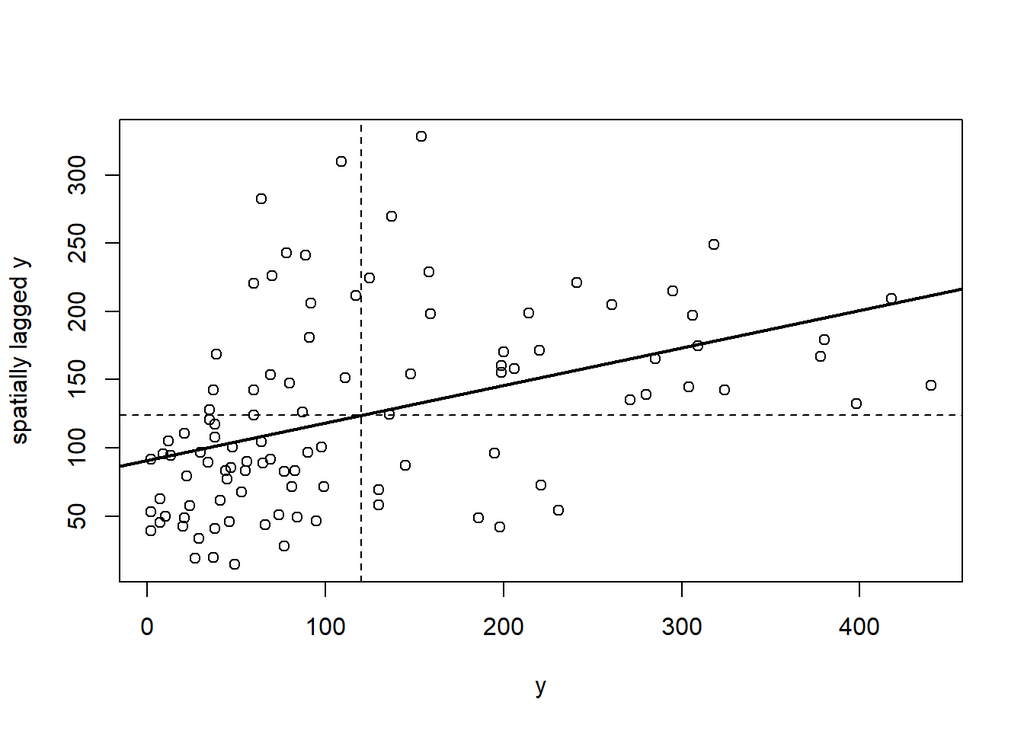

```r
plot(ams)
reg <- lm(ams[,2] ~ ams[,1])
abline(reg, lwd=2)
abline(h=mean(ams[,2]), lt=2)
abline(v=ybar, lt=2)
```

```r
coefficients(reg)[2]
```

```
##  ams[, 1]
## 0.2746281
```

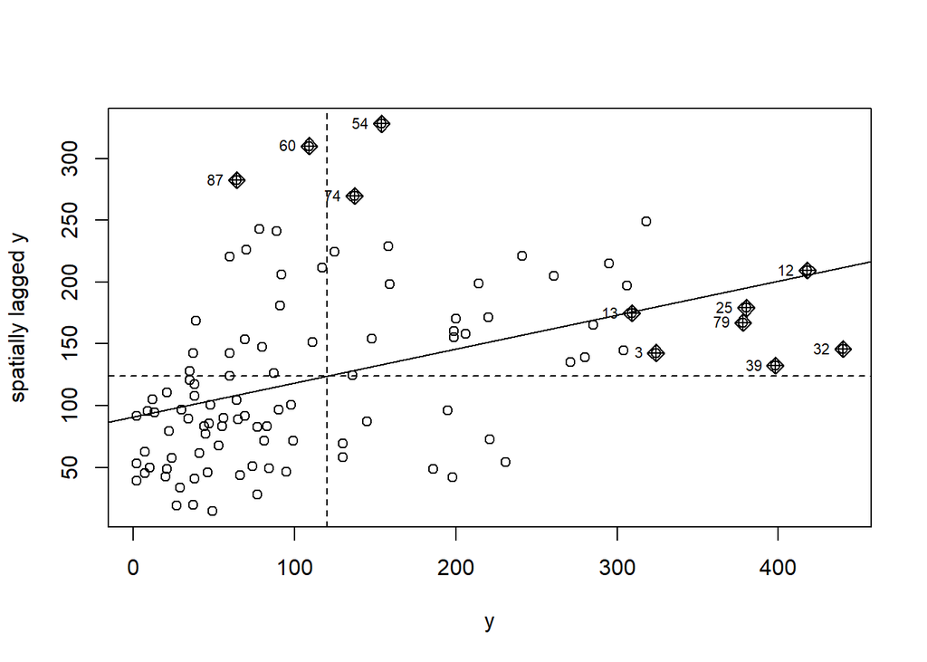

```r
# using built-in function
rwm <- mat2listw(wm, style='W')
moran.plot(y, rwm)
```

**Question 4**: Show how to use the ‘geary’ function to compute Geary’s C

```r
geary(pols$TB, ww, n, n-1, Szero(ww))
```

```
## $C
## [1] 0.7485823
##
## $K
## [1] 3.517442
```

**Question 5**: Write your own Monte Carlo simulation test to compute p-values for Moran’s I, replicating the results we obtained with the function from spdep. Show a figure similar to Figure 7.9 in OSU.

```r
# initialize array
mc_is = c()

#number of simulations
nsim = 99

for (i in 1:nsim){
  # shuffle y values
  y_sim = sample(y)
  # re-compute Moran's I
  val = moran(y_sim, ww, n=length(ww$neighbours), S0=Szero(ww))[[1]]
  # save value to array
  mc_is[i] = val
}

# get number of values above test value
num_above = length(which(mc_is > MI))

# compute p-value
p = (num_above + 1)/(nsim+1)

print('Monte Carlo simulation of Moran I')
```

```
## [1] "Monte Carlo simulation of Moran I"
```

```r
sprintf('number of simulations + 1 : %i', nsim+1)
```

```
## [1] "number of simulations + 1 : 100"
```

```r
sprintf('p-value: %s', p)
```

```
## [1] "p-value: 0.01"
```

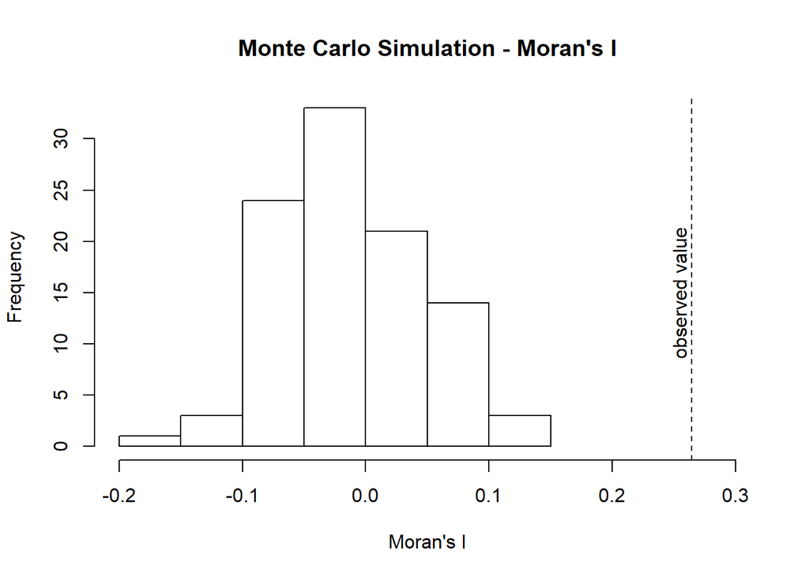

```r
# make plot
hist(mc_is, main="Monte Carlo Simulation - Moran's I", xlab="Moran's I", ylab="Frequency", xlim=c(-0.2, 0.3))
abline(v=MI, lty=2)
text(MI-0.01, 15, "observed value", srt=90)
```

**Question 6**: Write your own Geary C function, by completing the function below

```r
gearyC <- ((n-1)/sum((y - ybar)^2)) * sum(wm * (rep(y, times=n) - rep(y, each=n))^2) / (2 * sum(wm))

gearyC
```

```
## [1] 0.7485823
```